# EDA_LA_2

Reshma Itagi

2022-09-23

```r
df = read.csv('test_scores.csv')
head(df)
```

|  | school | school_setting | school_type | classroom | teaching_method | n_student | student_id | gender | lunch | pretest | posttest |
| --- | --- | --- | --- | --- | --- | --- | --- | --- | --- | --- | --- |
| 1 | ANKYI | Urban | Non-public | 6OL | Standard | 20 | 2FHT3 | Female | Does not qualify | 62 | 72 |
| 2 | ANKYI | Urban | Non-public | 6OL | Standard | 20 | 3JIVH | Female | Does not qualify | 66 | 79 |
| 3 | ANKYI | Urban | Non-public | 6OL | Standard | 20 | 3XOWE | Male | Does not qualify | 64 | 76 |
| 4 | ANKYI | Urban | Non-public | 6OL | Standard | 20 | 556O0 | Female | Does not qualify | 61 | 77 |
| 5 | ANKYI | Urban | Non-public | 6OL | Standard | 20 | 74LOE | Male | Does not qualify | 64 | 76 |
| 6 | ANKYI | Urban | Non-public | 6OL | Standard | 20 | 7YZO8 | Female | Does not qualify | 66 | 74 |

```r
library(dplyr)
```

```r
library(ggplot2)
```

```r
temp = df %>% filter(df$school == "ANKYI")
temp.aov = na.omit(aov(temp$pretest ~ temp$posttest, data = temp))
temp.aov
```

```
## Call:
##    aov(formula = temp$pretest ~ temp$posttest, data = temp)
##
## Terms:
##                 temp$posttest Residuals
## Sum of Squares       200.8709  168.3486
## Deg. of Freedom             1        39
##
## Residual standard error: 2.07765
## Estimated effects may be unbalanced
```

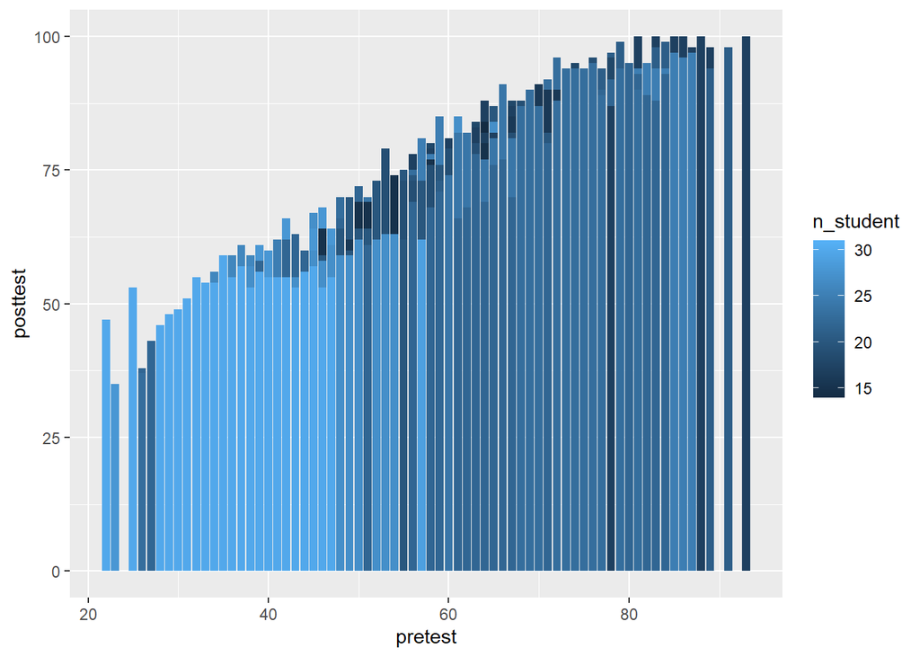

```r
ggplot(df,aes(x=pretest, fill=n_student, y=posttest))+geom_col(position ="dodge")
```

# Creating a Scatter Plot

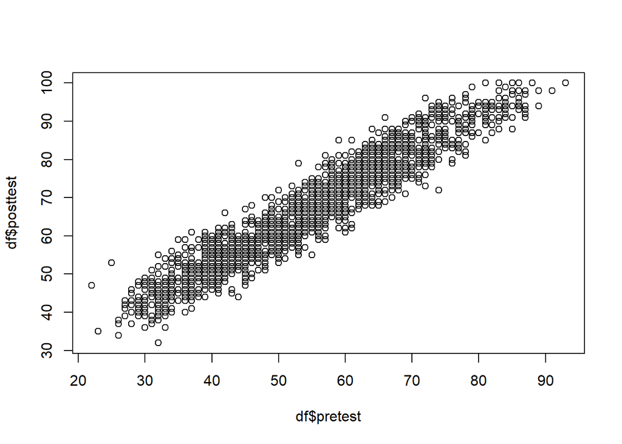

```r
plot(df$pretest, df$posttest)
```

```r
# Scatter plot with base graphics
```

# Scatter plot with ggplot 2

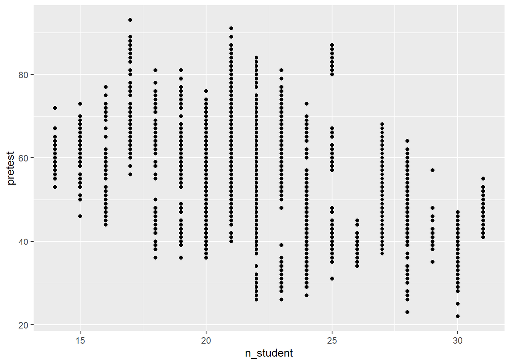

```r
library(ggplot2)
ggplot(df, aes(x = n_student, y = pretest)) +geom_point()
```

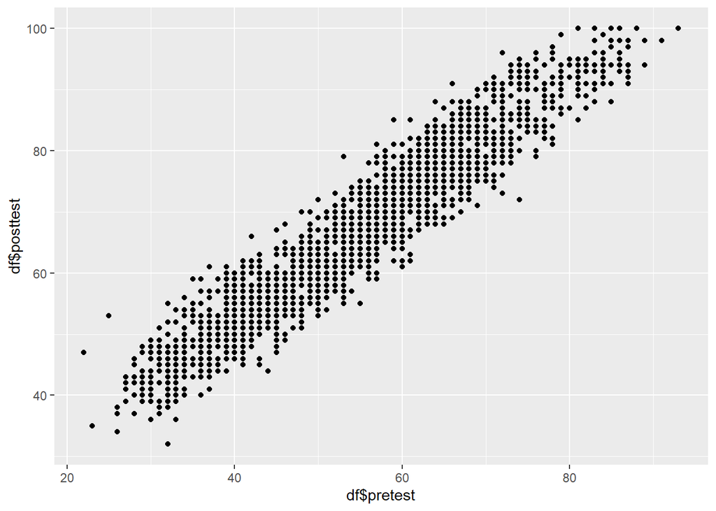

```r
ggplot(data = NULL, aes(x =df$pretest, y=df$posttest )) +
geom_point()
```

# Creating a Line Graph

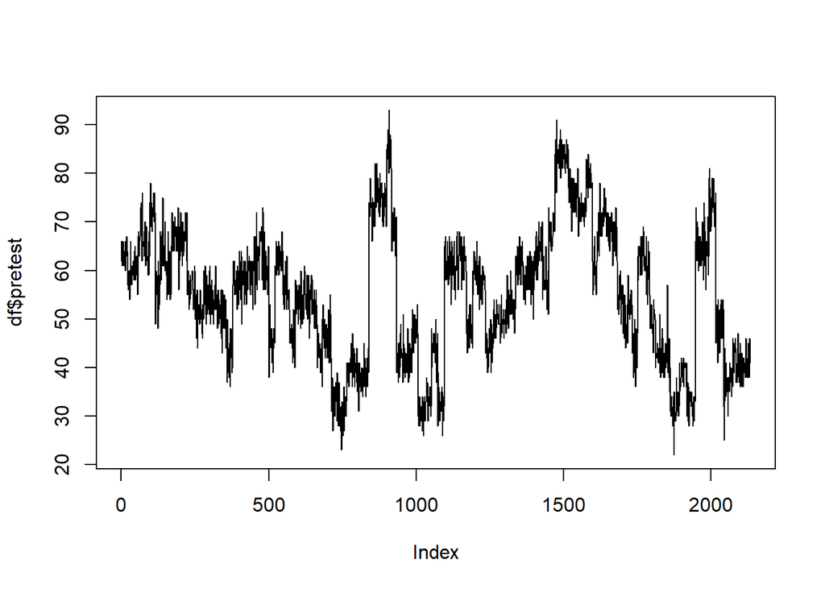

```r
plot(df$pretest,type = "l")
```

# Line graph with base graphics

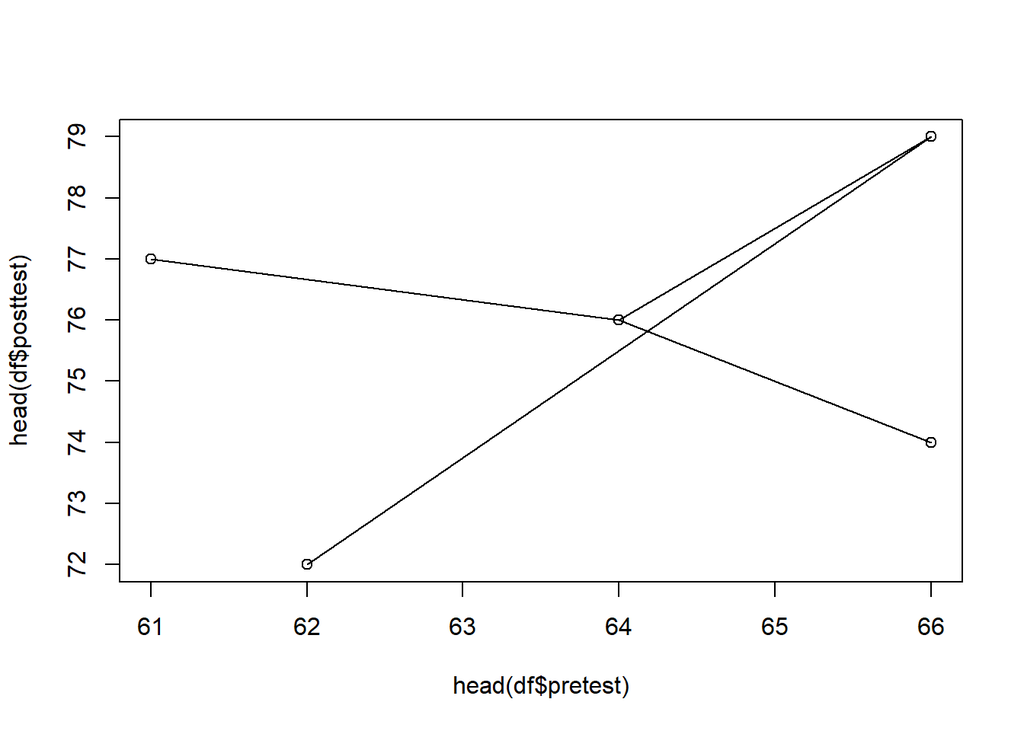

```r
plot(head(df$pretest),head(df$posttest),  type = "l")
points(head(df$pretest),head(df$posttest))
```

# Line graph with ggplot() and With points added to ggplot()

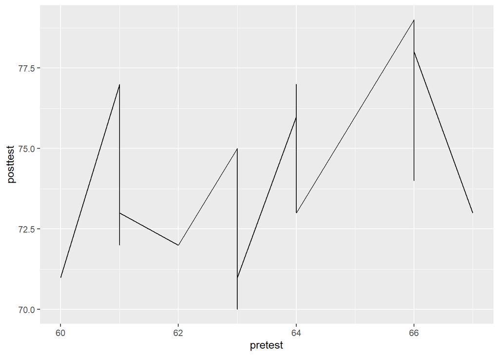

```r
ggplot(head(df,n=20), aes(x = pretest, y = posttest)) +geom_line()
```

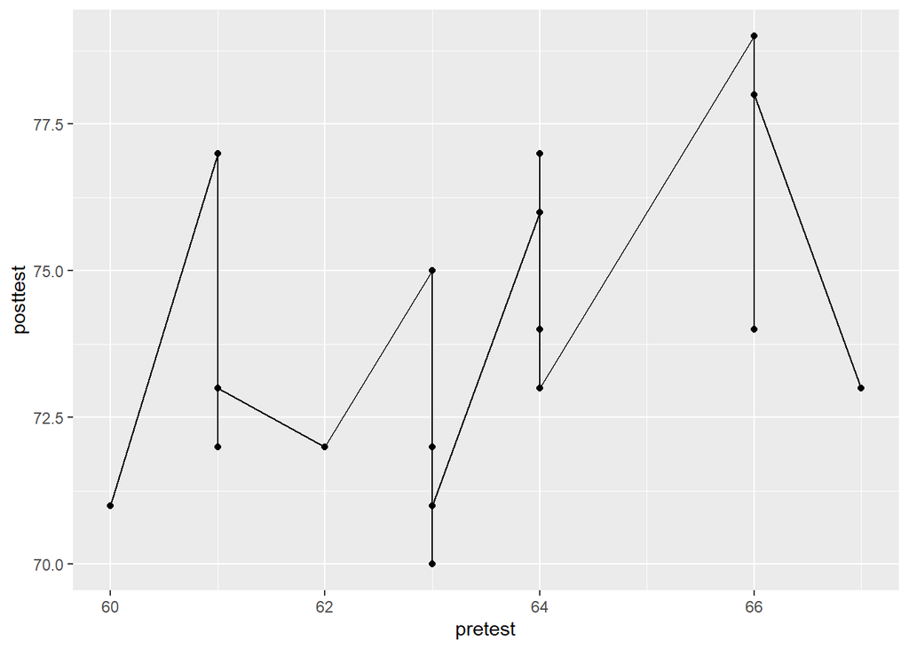

```r
ggplot(head(df,n=20), aes(x = pretest, y = posttest)) +geom_line()+geom_point()
```

# Creating a Bar Graph

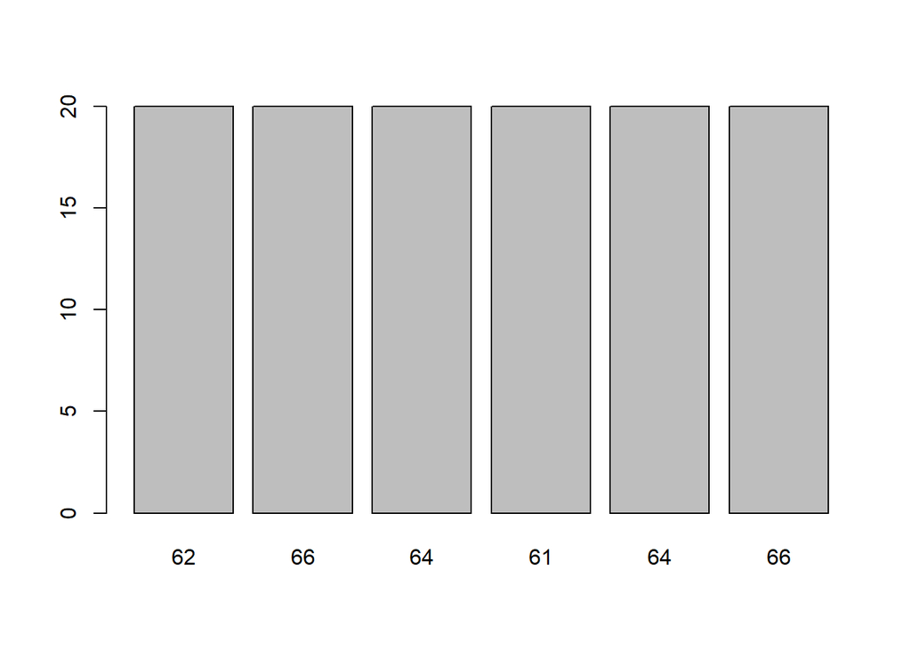

```r
barplot(head(df$n_student), names.arg = head(df$pretest))
```

# Generate a table of counts

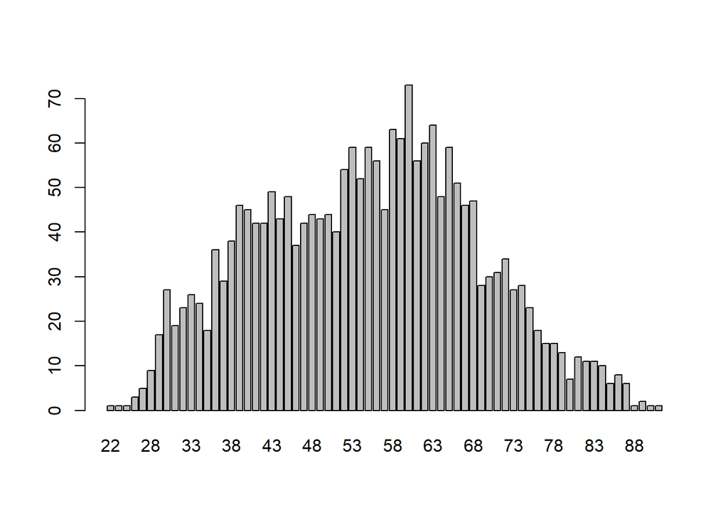

```r
barplot(table(df$pretest))
```

# Laoding ggplot2() package

```r
library(ggplot2)
```

# Bar graph of values. This uses the dataset data frame, with the

# “pretest” column for x values and the “posttest” column for y values.

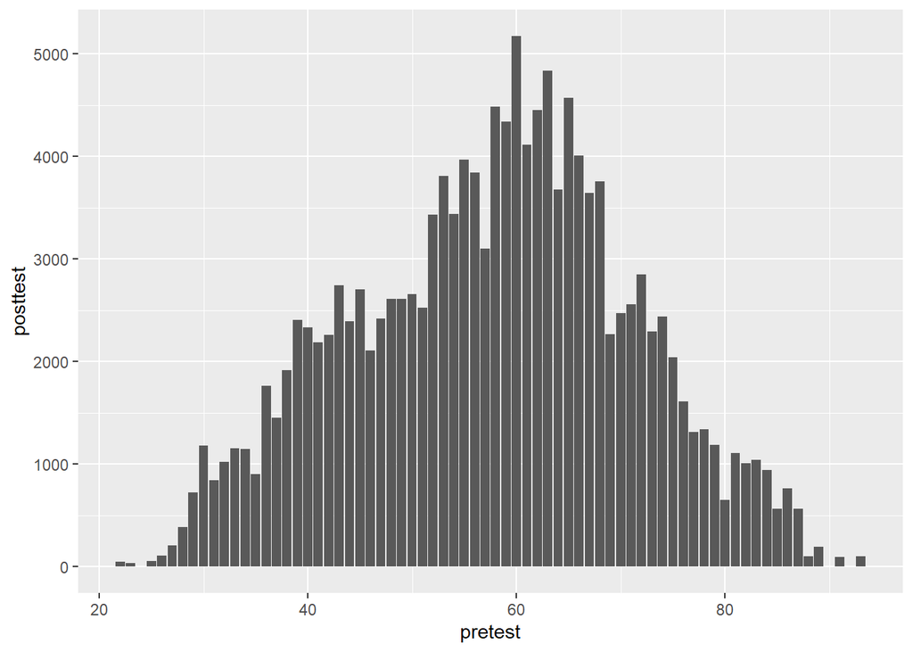

```r
ggplot(df, aes(x = pretest, y = posttest)) +geom_col()
```

# Convert the x variable to a factor, so that it is treated as discrete

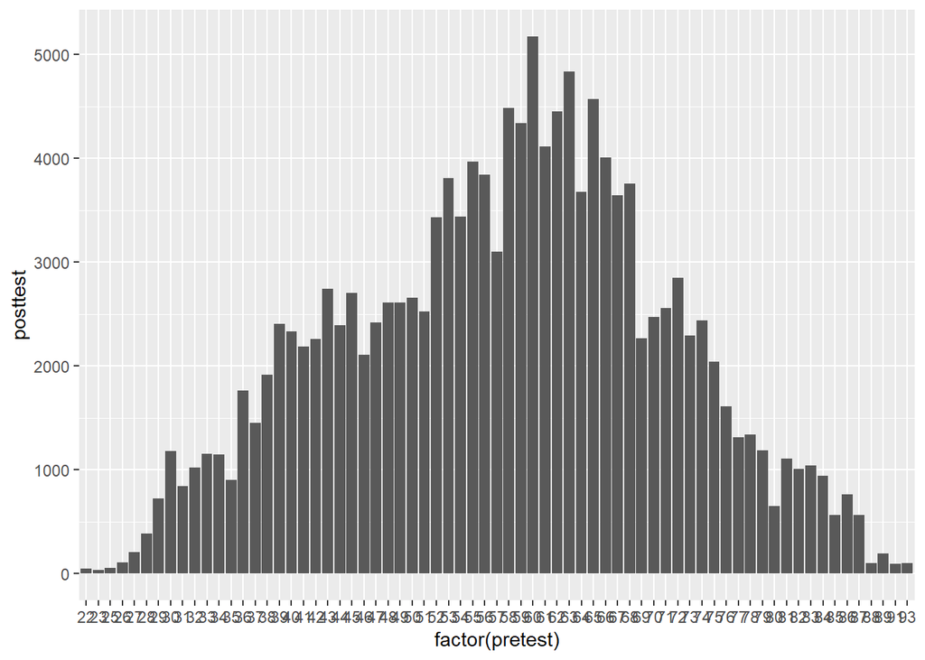

```r
ggplot(df, aes(x = factor(pretest), y = posttest)) +geom_col()
```

# Bar graph of counts. This uses the dataset data frame, with the “pretest” column for

# x position. The y position is calculated by counting the number of rows for

# each value of pretest.

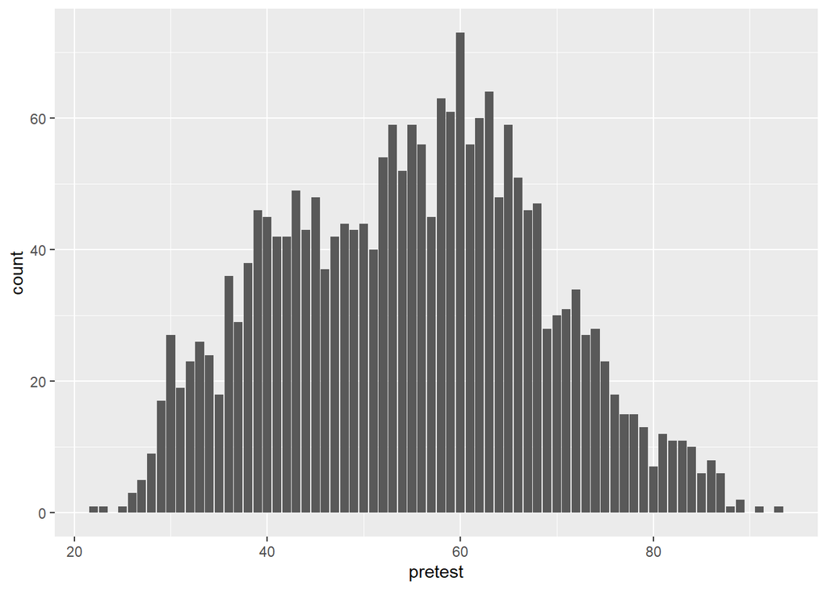

```r
ggplot(df, aes(x = pretest)) +
geom_bar()
```

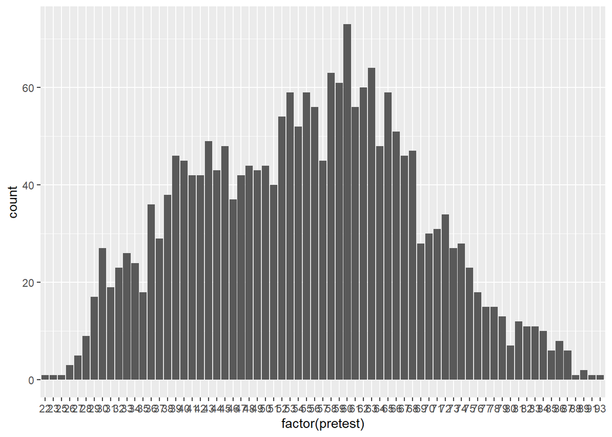

```r
# Bar graph of counts
ggplot(df, aes(x = factor(pretest))) +
geom_bar()
```

# Creating a Histogram

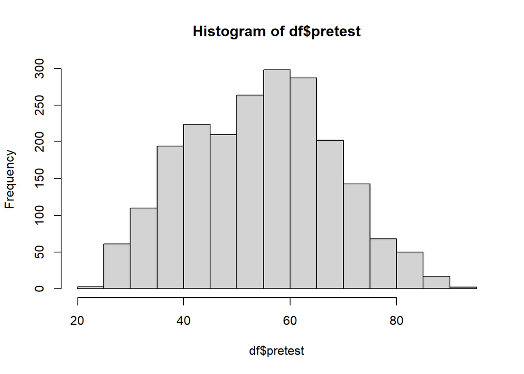

```r
hist(df$pretest)
```

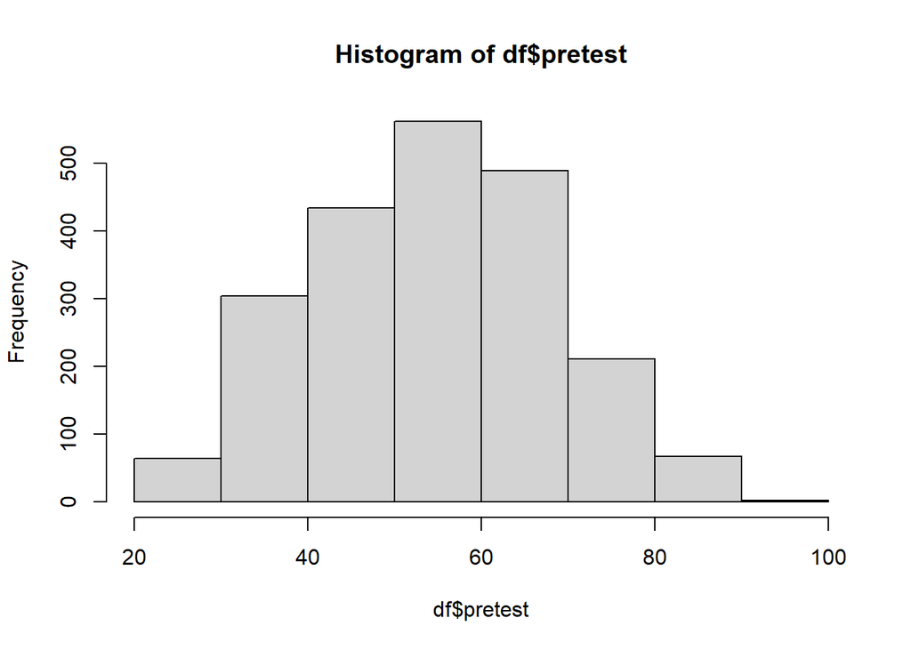

```r
# Specify approximate number of bins with breaks
hist(df$pretest, breaks = 10)
```

#ggplot2 histogram with default bin width (left); With wider bins (right)

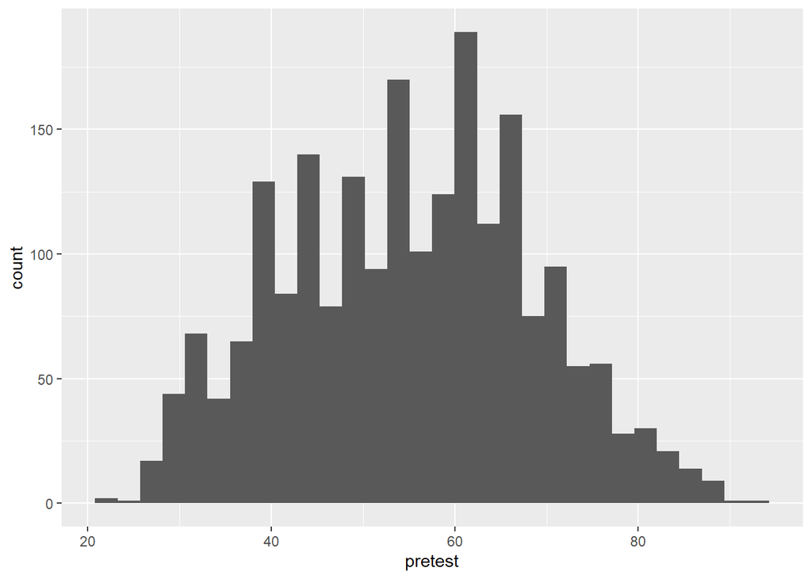

```r
ggplot(df, aes(x = pretest)) +
geom_histogram()
```

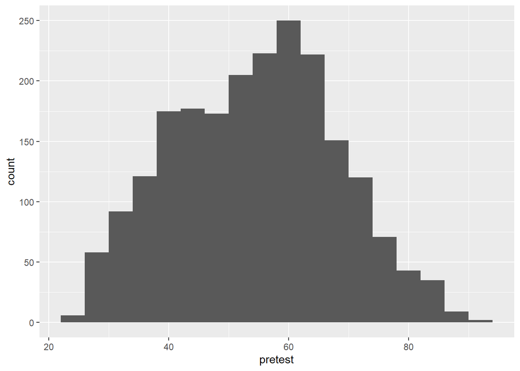

```r
ggplot(df, aes(x = pretest)) +
geom_histogram(binwidth = 4)
```

# Creating a Box Plot

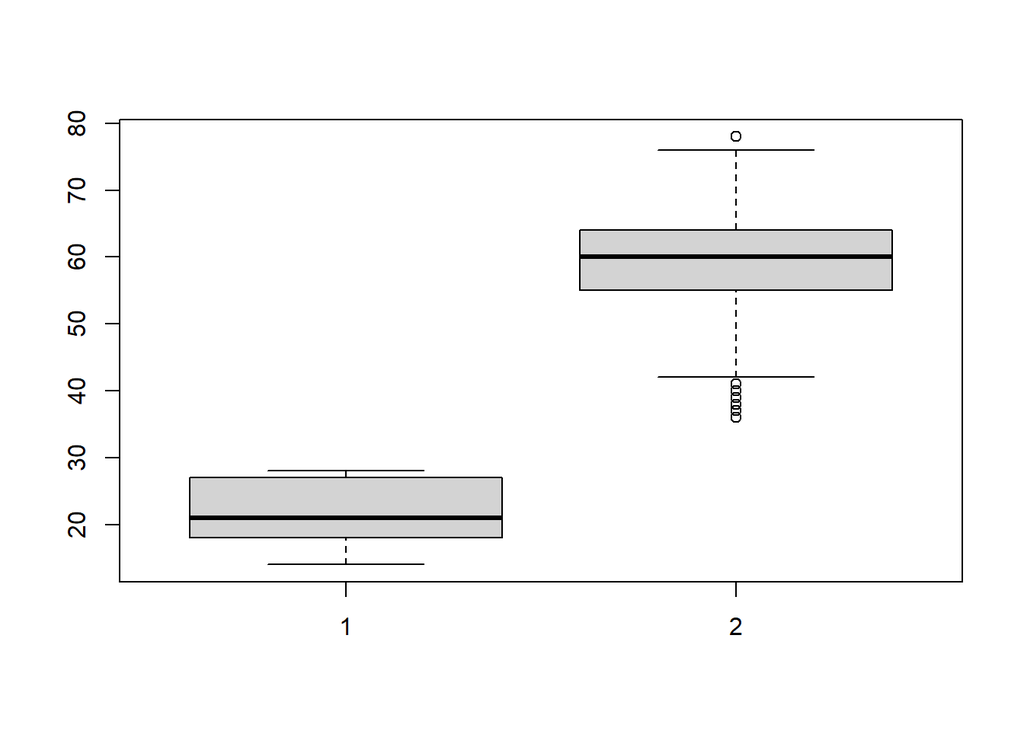

```r
boxplot(head(df$n_student,n=500), head(df$pretest,n=500))
```

# Make box plots for multiple variables, by combining the variables with interaction()

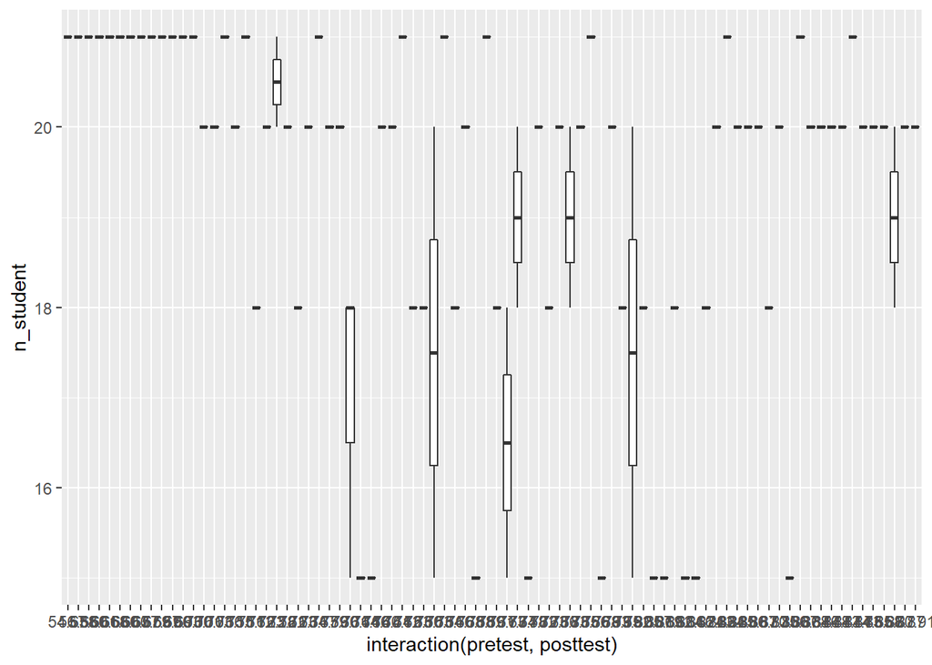

```r
ggplot(head(df,n=100), aes(x = interaction(pretest, posttest), y = n_student)) +
geom_boxplot()
```

# Making a Basic Histogram

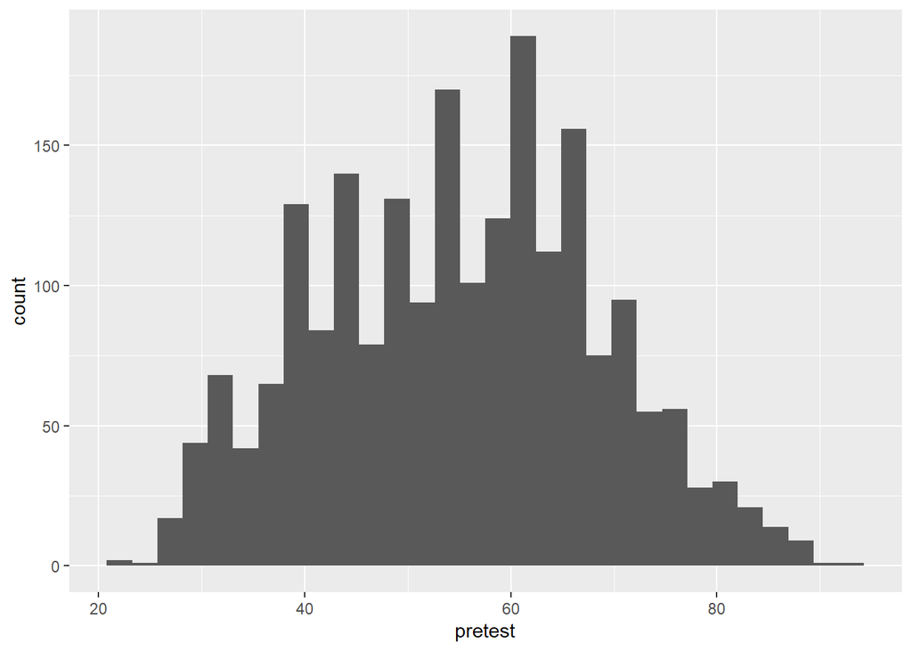

```r
ggplot(df, aes(x = pretest)) +geom_histogram()
```

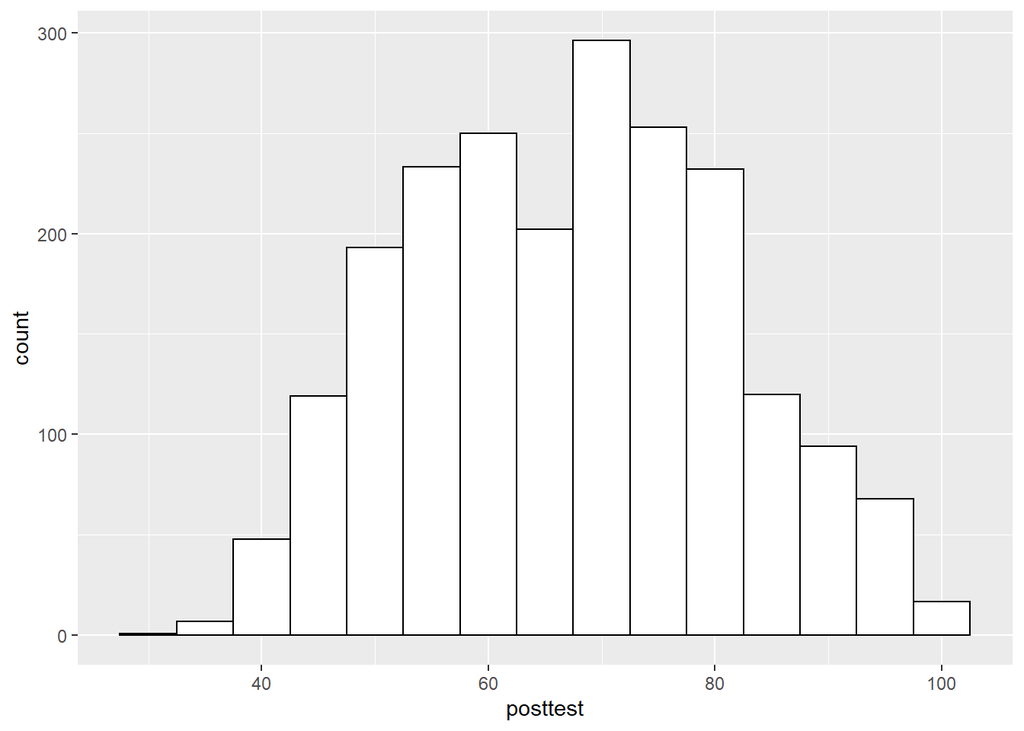

```r
ggplot(df, aes(x= posttest)) +
geom_histogram(binwidth = 5, fill = "white", colour = "black")
```

# Map pretest to fill, make the bars NOT stacked, and make them semitransparent

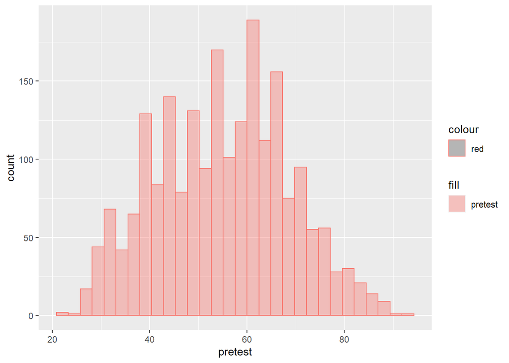

```r
ggplot(df, aes(x = pretest, fill ='pretest',colour='red' )) +
geom_histogram(position = "identity", alpha = 0.4)
```

# Making a Density Curve

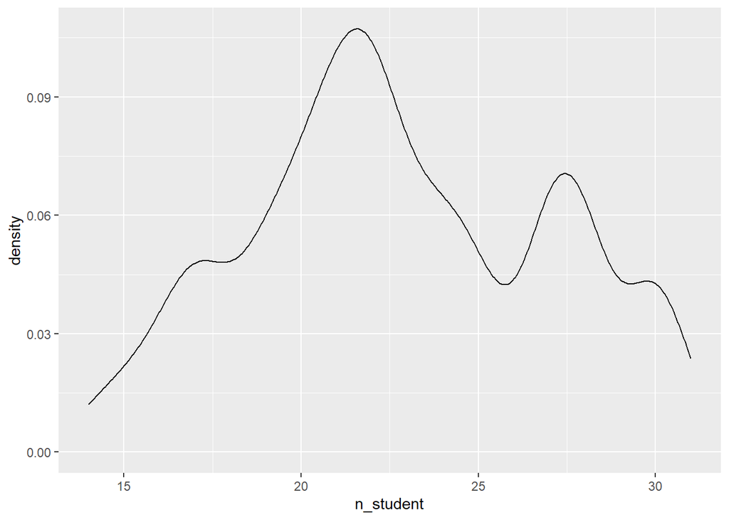

```r
ggplot(df, aes(x = n_student)) +geom_density()
```